# Descrição pacote class

Gabrlel e Paulo

05-06-2024

# Instalando e Importando o pacote

Inicialmente, antes da utilização das funções do pacote class, é necessário fazer a instalação e carregar o pacote. Após isso, podemos começar a utilização do pacote.

```r
options(repos = "https://cran.r-project.org")
install.packages("class")
library(class)
```

## batcSOM

Os mapas auto-organizados de Kohonen são uma forma rudimentar de escala multidimensional.

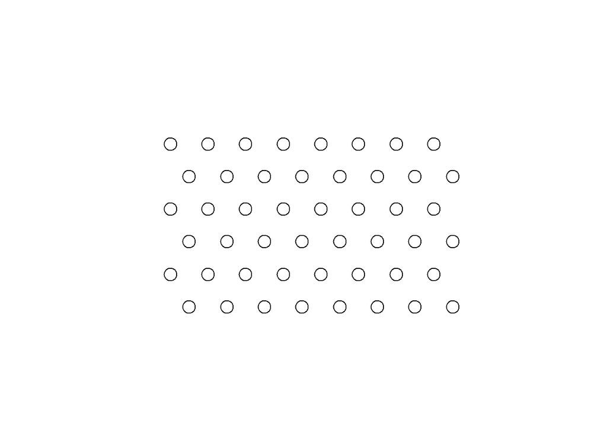

```r
require(graphics)
data(crabs, package = "MASS")
lcrabs <- log(crabs[, 4:8])
crabs.grp <- factor(c("B", "b", "O", "o")[rep(1:4, rep(50,4))])
gr <- somgrid(topo = "hexagonal")
crabs.som <- batchSOM(lcrabs, gr, c(4, 4, 2, 2, 1, 1, 1, 0, 0))
plot(crabs.som$grid)
```

## condense

a segunda função a ser explorada é o “condense” , essa função percorre o vertor da direita para a esquerda, tirando os iguais.

```r
data("iris3")
train <- rbind(iris3[1:25,,1], iris3[1:25,,2], iris3[1:25,,3])
test <- rbind(iris3[26:50,,1], iris3[26:50,,2], iris3[26:50,,3])
cl <- factor(c(rep("s",25), rep("c",25), rep("v",25)))
keep <- condense(train, cl)
```

```
## [1] 55
## [1] 32 55
## [1]  6 32 55
## [1]  6 32 55 64
## [1]  6 32 33 55 64
## [1]  6 32 33 48 55 64
## [1]  6 32 33 48 55 64 70
## [1]  6 32 33 48 55 61 64 70
## [1]  6 32 33 48 55 61 64 70 74
```

```r
knn(train[keep, , drop=FALSE], test, cl[keep])
```

```
##  [1] s s s s s s s s s s s s s s s s s s s s s s s s s c c v c c c c c v v c c c
## [39] c c v c c c c c c c c c v v v v v v v v c v v v v v v v v v v v v v v v v
## Levels: c s v
```

```r
keep2 <- reduce.nn(train, keep, cl)
knn(train[keep2, , drop=FALSE], test, cl[keep2])
```

```
##  [1] s s s s s s s s s s s s s s s s s s s s s s s s s c c v c c c c c v c c c c
## [39] c c v c c c c c c c c c v v v v v v v v c v v v v v v v v v v v v v v v v
## Levels: c s v
```

## KNN

A chave para o algoritmo kNN é determinar a distância entre o ponto de consulta e os outros pontos de dados. A determinação das métricas de distância permite o estabelecimento de limites de decisão. Esses limites criam diferentes regiões de pontos de dados. Existem diferentes métodos usados para calcular a distância , nesse caso usaremos a distancia euclidiana.

```r
grupo <- matrix(c(0.2,0.2,0.25,0.2,0.2,0.6,0.3,0.3,0.8,0.8,0.6,0.4,0.9,0.9),7,2,byrow = T)
rotulos = c("A","A","A","A","B","B","B")
grupo
```

```
##      [,1] [,2]
## [1,] 0.20  0.2
## [2,] 0.25  0.2
## [3,] 0.20  0.6
## [4,] 0.30  0.3
## [5,] 0.80  0.8
## [6,] 0.60  0.4
## [7,] 0.90  0.9
```

```r
testar_pt <- matrix(c(0.4,0.4,0.5,0.5,0.6,0.6,0.7,0.7,0.8,0.8),5,2,byrow = T)

library(class)
teste <- knn(grupo,testar_pt,rotulos,k=2,prob = FALSE)
teste
```

```
## [1] B B B B B
## Levels: A B
```

```r
data("iris3")
train <- rbind(iris3[,,1], iris3[,,2], iris3[,,3])
cl <- factor(c(rep("s",50), rep("c",50), rep("v",50)))
knn.cv(train, cl, k = 3, prob = FALSE)
```

```
##   [1] s s s s s s s s s s s s s s s s s s s s s s s s s s s s s s s s s s s s s
##  [38] s s s s s s s s s s s s s c c c c c c c c c c c c c c c c c c c c v c v c
##  [75] c c c c c c c c c v c c c c c c c c c c c c c c c c v v v v v v c v v v v
## [112] v v v v v v v v c v v v v v v v v v v v v v c v v v v v v v v v v v v v v
## [149] v v
## Levels: c s v
```

```r
attributes(.Last.value)
```

```
## $names
## [1] "help_type"
```

## knn.1

classifica da mesma forma que o knn convencional, porem utiliza como criterio apenas um vizinho mais proximo, em caso de empate a classificações é feita de forma aleatoria.

```r
data("iris3")
train <- rbind(iris3[1:25,,1], iris3[1:25,,2], iris3[1:25,,3])
test <- rbind(iris3[26:50,,1], iris3[26:50,,2], iris3[26:50,,3])
cl <- factor(c(rep("s",25), rep("c",25), rep("v",25)))
knn1(train, test, cl)
```

```
##  [1] s s s s s s s s s s s s s s s s s s s s s s s s s c c c c c c c c v c c c c
## [39] c c c c c c c c c c c c v v c v v v v v c v v v v c v v v v v v v v v v v
## Levels: c s v
```

## lvq1

Seleciona exemplos aleatoriamente com substituição e ajusta o exemplo mais próximo um.

```r
data("iris3")
train <- rbind(iris3[1:25,,1], iris3[1:25,,2], iris3[1:25,,3])
test <- rbind(iris3[26:50,,1], iris3[26:50,,2], iris3[26:50,,3])
cl <- factor(c(rep("s",25), rep("c",25), rep("v",25)))
cd <- lvqinit(train, cl, 10)
lvqtest(cd, train)
```

```
##  [1] s s s s s s s s s s s s s s s s s s s s s s s s s c c c c c c c c c c c c c
## [39] c c c c c c c c c c c c v c v v v v c v v v v v v c v v v v v c v c v c v
## Levels: c s v
```

```r
cd0 <- olvq1(train, cl, cd)
lvqtest(cd0, train)
```

```
##  [1] s s s s s s s s s s s s s s s s s s s s s s s s s c c c c c c c c c c c c c
## [39] c c c c c c c c c c c c v v v v v v c v v v v v v v v v v v v c v v v c v
## Levels: c s v
```

```r
cd1 <- lvq1(train, cl, cd0)
lvqtest(cd1, train)
```

```
##  [1] s s s s s s s s s s s s s s s s s s s s s s s s s c c c c c c c c c c c c c
## [39] c c c c c c c c c c c c v v v v v v c v v v v v v v v v v v v v v v v v v
## Levels: c s v
```

## lvq2

Seleciona exemplos aleatoriamente com substituição e ajusta os dois exemplos mais próximos, se um estiver correto e o outro incorreto.

```r
train <- rbind(iris3[1:25,,1], iris3[1:25,,2], iris3[1:25,,3])
test <- rbind(iris3[26:50,,1], iris3[26:50,,2], iris3[26:50,,3])
cl <- factor(c(rep("s",25), rep("c",25), rep("v",25)))
cd <- lvqinit(train, cl, 10)
lvqtest(cd, train)
```

```
##  [1] s s s s s s s s s s s s s s s s s s s s s s s s s c c v c c c c c c c c c c
## [39] c c c c c c c c c c c c v c v v v v c v v v v v v c v v v v v c v c v c v
## Levels: c s v
```

```r
cd0 <- olvq1(train, cl, cd)
lvqtest(cd0, train)
```

```
##  [1] s s s s s s s s s s s s s s s s s s s s s s s s s c c c c c c c c c c c c c
## [39] c c c c c c c c c c c c v v v v v v c v v v v v v v v v v v v c v v v c v
## Levels: c s v
```

```r
cd2 <- lvq2(train, cl, cd0)
lvqtest(cd2, train)
```

```
##  [1] s s s s s s s s s s s s s s s s s s s s s s s s s c c c c c c c c c c c c c
## [39] c c c c c c c c c c c c v v v v v v c v v v v v v v v v v v v v v v v v v
## Levels: c s v
```

## lvq3

```r
train <- rbind(iris3[1:25,,1], iris3[1:25,,2], iris3[1:25,,3])
test <- rbind(iris3[26:50,,1], iris3[26:50,,2], iris3[26:50,,3])
cl <- factor(c(rep("s",25), rep("c",25), rep("v",25)))
cd <- lvqinit(train, cl, 10)
lvqtest(cd, train)
```

```
##  [1] s s s s s s s s s s s s s s s s s s s s s s s s s c c c c c c c c c c c c c
## [39] c c c c c c c c c c c c v v v v v v v v v v c v v v v v v v v v v v v c v
## Levels: c s v
```

```r
cd0 <- olvq1(train, cl, cd)
lvqtest(cd0, train)
```

```
##  [1] s s s s s s s s s s s s s s s s s s s s s s s s s c c c c c c c c c c c c c
## [39] c c c c c c c c c c c c v v v v v v c v v v v v v v v v v v v v v v v v v
## Levels: c s v
```

```r
cd3 <- lvq3(train, cl, cd0)
lvqtest(cd3, train)
```

```
##  [1] s s s s s s s s s s s s s s s s s s s s s s s s s c c c c c c c c c c c c c
## [39] c c c c c c c c c c c c v v v v v v v v v v v v v v v v v v v v v v v v v
## Levels: c s v
```

## lvqinit

Constroi um livro de códigos inicial para métodos LVQ.

```r
train <- rbind(iris3[1:25,,1], iris3[1:25,,2], iris3[1:25,,3])
test <- rbind(iris3[26:50,,1], iris3[26:50,,2], iris3[26:50,,3])
cl <- factor(c(rep("s",25), rep("c",25), rep("v",25)))
cd <- lvqinit(train, cl, 10)
cd
```

```
## $x
##       Sepal L. Sepal W. Petal L. Petal W.
##  [1,]      6.2      2.2      4.5      1.5
##  [2,]      6.0      2.2      4.0      1.0
##  [3,]      6.1      2.8      4.0      1.3
##  [4,]      4.6      3.4      1.4      0.3
##  [5,]      5.1      3.5      1.4      0.3
##  [6,]      4.3      3.0      1.1      0.1
##  [7,]      6.5      3.0      5.8      2.2
##  [8,]      7.1      3.0      5.9      2.1
##  [9,]      7.7      2.6      6.9      2.3
##
## $cl
## [1] c c c s s s v v v
## Levels: c s v
```

## lvetest

Classifica um conjunto de testes por 1-NN de um livro de códigos LVQ especificado.

```r
train <- rbind(iris3[1:25,,1], iris3[1:25,,2], iris3[1:25,,3])
test <- rbind(iris3[26:50,,1], iris3[26:50,,2], iris3[26:50,,3])
cl <- factor(c(rep("s",25), rep("c",25), rep("v",25)))
cd <- lvqinit(train, cl, 10)
lvqtest(cd, train)
```

```
##  [1] s s s s s s s s s s s s s s s s s s s s s s s s s c c c c c c c c c c c c c
## [39] c c c c c c c c c c c c v v v v v v c v v v v v v v v v v v v c v v v c v
## Levels: c s v
```

## multiedit

divide o banco de treino em varias partes para aplicar o knn

```r
tr <- sample(1:50, 25)
train <- rbind(iris3[tr,,1], iris3[tr,,2], iris3[tr,,3])
test <- rbind(iris3[-tr,,1], iris3[-tr,,2], iris3[-tr,,3])
cl <- factor(c(rep(1,25),rep(2,25), rep(3,25)), labels=c("s", "c", "v"))
table(cl, knn(train, test, cl, 3))
```

```
##
## cl   s  c  v
##   s 25  0  0
##   c  0 23  2
##   v  0  3 22
```

```r
ind1 <- multiedit(train, cl, 5)
```

```
## pass 1 size 73
```

```
## pass 2 size 71
```

```
## pass 3 size 69
```

```
## pass 4 size 67
```

```
## pass 5 size 67
```

```
## pass 6 size 67
```

```
## pass 7 size 62
```

```
## pass 8 size 62
```

```
## pass 9 size 62
```

```
## pass 10 size 62
```

```
## pass 11 size 62
```

```r
length(ind1)
```

```
## [1] 62
```

```r
table(cl, knn(train[ind1, , drop=FALSE], test, cl[ind1], 1))
```

```
##
## cl   s  c  v
##   s 25  0  0
##   c  0 24  1
##   v  0  1 24
```

```r
ntrain <- train[ind1,]; ncl <- cl[ind1]
ntrain
```

```
##       Sepal L. Sepal W. Petal L. Petal W.
##  [1,]      5.0      3.2      1.2      0.2
##  [2,]      4.8      3.4      1.6      0.2
##  [3,]      5.1      3.8      1.5      0.3
##  [4,]      4.8      3.4      1.9      0.2
##  [5,]      5.0      3.6      1.4      0.2
##  [6,]      5.2      4.1      1.5      0.1
##  [7,]      5.5      4.2      1.4      0.2
##  [8,]      5.0      3.3      1.4      0.2
##  [9,]      4.4      2.9      1.4      0.2
## [10,]      4.9      3.6      1.4      0.1
## [11,]      4.6      3.2      1.4      0.2
## [12,]      4.7      3.2      1.3      0.2
## [13,]      4.6      3.6      1.0      0.2
## [14,]      4.8      3.0      1.4      0.3
```

[output cut: 48 more lines]

```r
#mostra todosa to tipo do ind especificado
```

## olvq1

Move exemplos em um livro de códigos para representar melhor o conjunto de treinamento.

```r
train <- rbind(iris3[1:25,,1], iris3[1:25,,2], iris3[1:25,,3])
test <- rbind(iris3[26:50,,1], iris3[26:50,,2], iris3[26:50,,3])
cl <- factor(c(rep("s",25), rep("c",25), rep("v",25)))
cd <- lvqinit(train, cl, 10)
lvqtest(cd, train)
```

```
##  [1] s s s s s s s s s s s s s s s s s s s s s s s s s c c c c c c c c c c c c c
## [39] c c c c c v c c c v c c v v v v v v c v v v c v v v v c v v v v v v v v v
## Levels: c s v
```

```r
cd1 <- olvq1(train, cl, cd)
lvqtest(cd1, train)
```

```
##  [1] s s s s s s s s s s s s s s s s s s s s s s s s s c c c c c c c c c c c c c
## [39] c c c c c c c c c c c c v v v v v v c v v v v v v v v v v v v v v v v v v
## Levels: c s v
```

## reduce.nn

Reduza o conjunto de treinamento para um classificador k-NN. Usado após condensação.

```r
train <- rbind(iris3[1:25,,1], iris3[1:25,,2], iris3[1:25,,3])
test <- rbind(iris3[26:50,,1], iris3[26:50,,2], iris3[26:50,,3])
cl <- factor(c(rep("s",25), rep("c",25), rep("v",25)))
keep <- condense(train, cl)
```

```
## [1] 37
## [1] 22 37
## [1] 22 37 51
## [1] 22 37 51 57
## [1] 22 35 37 51 57
## [1] 22 35 37 51 57 70
## [1] 22 35 37 44 51 57 70
## [1] 22 35 37 44 48 51 57 70
## [1] 22 35 37 44 48 51 57 70 74
##  [1] 22 35 37 44 46 48 51 57 70 74
##  [1] 22 28 35 37 44 46 48 51 57 70 74
##  [1] 22 28 35 37 44 46 48 51 57 70 72 74
##  [1] 22 28 35 37 44 46 48 51 57 63 70 72 74
```

```r
knn(train[keep,], test, cl[keep])
```

```
##  [1] s s s s s s s s s s s s s s s s s s s s s s s s s c c c c c c c c v c c c c
## [39] c c c c c c c c c c c c v v c v v v v v c v v v v c v v v v v v v v v v c
## Levels: c s v
```

```r
keep2 <- reduce.nn(train, keep, cl)
knn(train[keep2,], test, cl[keep2])
```

```
##  [1] s s s s s s s s s s s s s s s s s s s s s s s s s c c c c c c c c v c c c c
## [39] c c c c c c c c c c c c v v c v v v v v c v v v v c v v v v v v v v v v c
## Levels: c s v
```

## SOM

Os mapas auto-organizados de Kohonen são uma forma rudimentar de escala multidimensional.

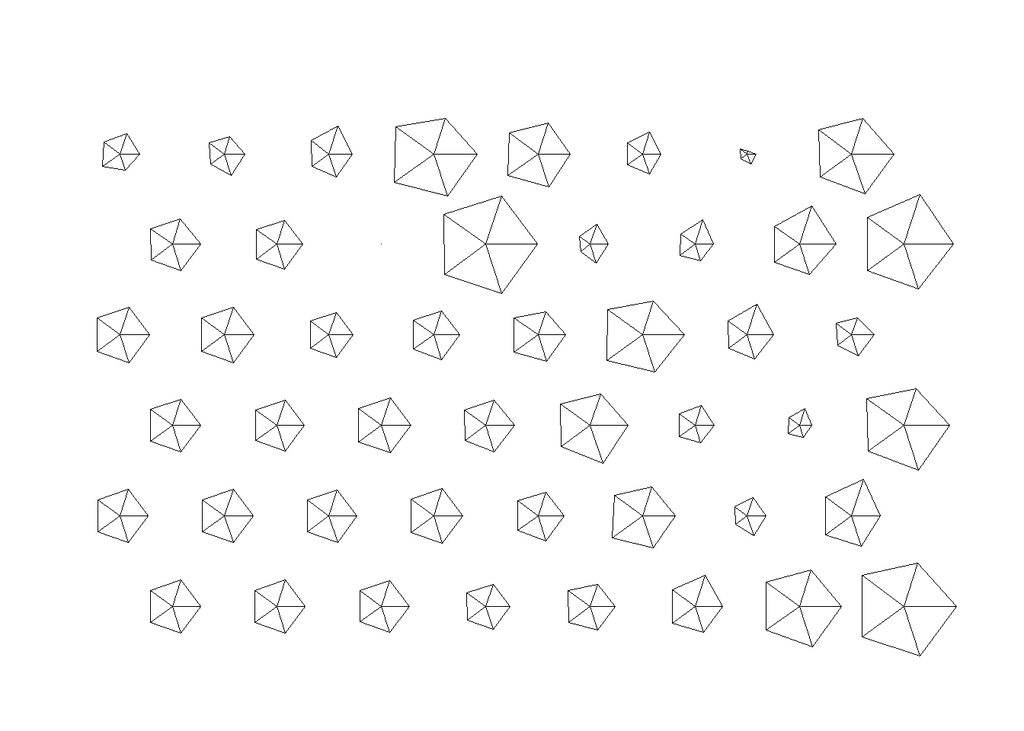

```r
require(graphics)
data(crabs, package = "MASS")
lcrabs <- log(crabs[, 4:8])
crabs.grp <- factor(c("B", "b", "O", "o")[rep(1:4, rep(50,4))])
gr <- somgrid(topo = "hexagonal")
crabs.som <- SOM(lcrabs, gr)
plot(crabs.som)
```

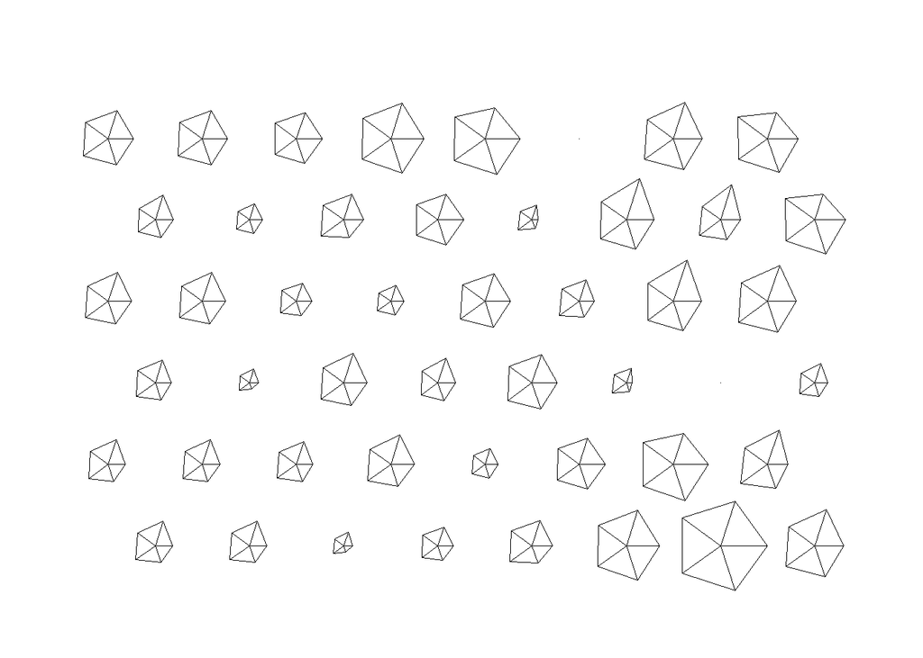

```r
## 2-phase training
crabs.som2 <- SOM(lcrabs, gr,
alpha = list(seq(0.05, 0, length.out = 1e4), seq(0.02, 0, length.out = 1e5)),
radii = list(seq(8, 1, length.out = 1e4), seq(4, 1, length.out = 1e5)))
plot(crabs.som2)
```